# PROJECT COPY

```python
# Import libraries as required
import pandas as pd
import numpy as np
import matplotlib.pyplot as plt
pd.set_option('display.max_rows', 10)

from collections import Counter
from timeit import timeit
from sklearn.ensemble import RandomForestClassifier
from sklearn.feature_extraction.text import CountVectorizer
from sklearn.linear_model import LogisticRegression
from sklearn.metrics import accuracy_score, confusion_matrix, ConfusionMatrixDisplay
from sklearn.model_selection import train_test_split
from sklearn.neural_network import MLPClassifier
from sklearn.preprocessing import LabelEncoder
import nltk
from nltk.corpus import stopwords
import re
from wordcloud import WordCloud, STOPWORDS, ImageColorGenerator
```

```python
df = pd.read_csv('project.csv')
df
```

|  | Labels | Messages |
| --- | --- | --- |
| 0 | ham | Go until jurong point, crazy.. Available only ... |
| 1 | ham | Ok lar... Joking wif u oni... |
| 2 | spam | Free entry in 2 a wkly comp to win FA Cup fina... |
| 3 | ham | U dun say so early hor... U c already then say... |
| 4 | ham | Nah I don't think he goes to usf, he lives aro... |
| ... | ... | ... |
| 5567 | spam | This is the 2nd time we have tried 2 contact u... |
| 5568 | ham | Will ü b going to esplanade fr home? |
| 5569 | ham | Pity, * was in mood for that. So...any other s... |
| 5570 | ham | The guy did some bitching but I acted like i'd... |
| 5571 | ham | Rofl. Its true to its name |

5572 rows × 2 columns

A section of the dataset.

```python
# To check if there are NaN Values.
df.isnull().sum()
```

```
Labels      0
Messages    0
dtype: int64
```

```python
df.info()
```

```
<class 'pandas.core.frame.DataFrame'>
RangeIndex: 5572 entries, 0 to 5571
Data columns (total 2 columns):
 #   Column    Non-Null Count  Dtype
---  ------    --------------  -----
 0   Labels    5572 non-null   object
 1   Messages  5572 non-null   object
dtypes: object(2)
memory usage: 87.2+ KB
```

The dataset comprises 5572 entries of SMS message and their corresponding Label.The data is stored as objects, which allows for text and numerical values to be stored. Notably, the DataFrame does not contain any null values, indicating that the dataset has undergone preprocessing.

```python
from collections import Counter
cnt2 = Counter()
for word2 in (df["Messages"]):
    cnt2[word2] += 1
cnt2
```

[output not shown]

[output cut: 946 more lines]

[output not shown]

Each message occurrence was counted.

```python
# Checking for duplicate data
duplicate_rows = df[df.duplicated()]
print("Duplicate rows:")
print(duplicate_rows)

# Removing duplicate rows
df = df.drop_duplicates()

# Removing stop words
nltk.download('stopwords')
stop_words = set(stopwords.words('english'))
df['text_without_stopwords'] = df['Messages'].apply(lambda x: ' '.join([word for word in str(x).split() if word.lower() not in stop_words]))

# Handling special characters
df['cleaned_text'] = df['text_without_stopwords'].apply(lambda x: re.sub(r'[^a-zA-Z0-9\s]', '', str(x)))

# Print the preprocessed DataFrame
print("Preprocessed DataFrame:")
print(df.head())
```

```
Duplicate rows:
     Labels                                           Messages
103     ham  As per your request 'Melle Melle (Oru Minnamin...
154     ham  As per your request 'Melle Melle (Oru Minnamin...
207     ham  As I entered my cabin my PA said, '' Happy B'd...
223     ham                             Sorry, I'll call later
326     ham                   No calls..messages..missed calls
...     ...                                                ...
5524   spam  You are awarded a SiPix Digital Camera! call 0...
5535    ham  I know you are thinkin malaria. But relax, chi...
5539    ham                         Just sleeping..and surfing
5553    ham                        Hahaha..use your brain dear
5558    ham                             Sorry, I'll call later

[403 rows x 2 columns]
```

```
Preprocessed DataFrame:
  Labels                                           Messages  \
0    ham  Go until jurong point, crazy.. Available only ...
1    ham                      Ok lar... Joking wif u oni...
2   spam  Free entry in 2 a wkly comp to win FA Cup fina...
3    ham  U dun say so early hor... U c already then say...
4    ham  Nah I don't think he goes to usf, he lives aro...

                              text_without_stopwords  \
0  Go jurong point, crazy.. Available bugis n gre...
1                      Ok lar... Joking wif u oni...
2  Free entry 2 wkly comp win FA Cup final tkts 2...
3          U dun say early hor... U c already say...
4            Nah think goes usf, lives around though

                                        cleaned_text
0  Go jurong point crazy Available bugis n great ...
1                            Ok lar Joking wif u oni
2  Free entry 2 wkly comp win FA Cup final tkts 2...
3                U dun say early hor U c already say
4             Nah think goes usf lives around though
```

The data was cleaned by removing special characters, stop words and duplicate messages.

```python
# Convert all words in the 'Messages' column to lowercase
df['Messages'] = df['Messages'].str.lower()

# Remove punctuation marks from the 'Messages' column
df['Messages'] = df['Messages'].str.replace(r'[^\w\s]', '')

# Remove words with less than three letters
df['Messages'] = df['Messages'].apply(lambda x: ' '.join([word for word in str(x).split() if len(word) >= 3]))

# Print the updated DataFrame
print(df)
```

```
     Labels                                           Messages  \
0       ham  until jurong point crazy available only bugis ...
1       ham                                 lar joking wif oni
2      spam  free entry wkly comp win cup final tkts 21st m...
3       ham                 dun say early hor already then say
4       ham   nah dont think goes usf lives around here though
...     ...                                                ...
5567   spam  this the 2nd time have tried contact have won ...
5568    ham                          will going esplanade home
5569    ham     pity was mood for that soany other suggestions
5570    ham  the guy did some bitching but acted like inter...
5571    ham                             rofl its true its name

                                 text_without_stopwords  \
0     Go jurong point, crazy.. Available bugis n gre...
```

[output cut: 25 more lines]

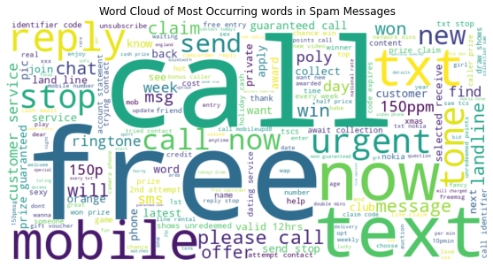

```python
# Filter the DataFrame to get only spam messages
spam_df = df[df['Labels'] == 'spam']

# Concatenate all spam messages into a single string
spam_text = ' '.join(spam_df['Messages'])

# Generate the word cloud
wordcloud = WordCloud(width=800, height=400, background_color='white').generate(spam_text)

# Plot the word cloud
plt.figure(figsize=(10, 5))
plt.imshow(wordcloud, interpolation='bilinear')
plt.axis('off')
plt.title('Word Cloud of Most Occurring words in Spam Messages')
plt.show()
```

A Word Cloud was used to show the most occurring words in the spam messages.

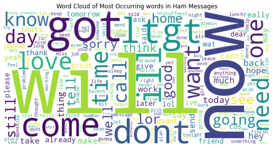

```python
# Filter the DataFrame to get only spam messages
ham_df = df[df['Labels'] == 'ham']

# Concatenate all spam messages into a single string
ham_text = ' '.join(ham_df['Messages'])

# Generate the word cloud
wordcloud = WordCloud(width=800, height=400, background_color='white').generate(ham_text)

# Plot the word cloud
plt.figure(figsize=(10, 5))
plt.imshow(wordcloud, interpolation='bilinear')
plt.axis('off')
plt.title('Word Cloud of Most Occurring words in Ham Messages')
plt.show()
```

A Word Cloud was used to show the most occurring words in the ham messages.

```python
df.info()
```

```
<class 'pandas.core.frame.DataFrame'>
Int64Index: 5169 entries, 0 to 5571
Data columns (total 4 columns):
 #   Column                  Non-Null Count  Dtype
---  ------                  --------------  -----
 0   Labels                  5169 non-null   object
 1   Messages                5169 non-null   object
 2   text_without_stopwords  5169 non-null   object
 3   cleaned_text            5169 non-null   object
dtypes: object(4)
memory usage: 201.9+ KB
```

After preprocessing the dataset, information about the dataset was accessed. The dataset is made up of 5169 messages with their corresponding Labels.

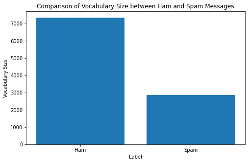

```python
# Create an instance of CountVectorizer for ham messages
ham_vectorizer = CountVectorizer()

# Fit the vectorizer on the 'Messages' column of ham messages to learn the vocabulary
ham_vectorizer.fit(df[df['Labels'] == 'ham']['Messages'])

# Get the vocabulary (unique words) for ham messages
ham_vocabulary = ham_vectorizer.get_feature_names()

# Calculate the vocabulary size for ham messages
ham_vocabulary_size = len(ham_vocabulary)

# Create an instance of CountVectorizer for spam messages
spam_vectorizer = CountVectorizer()

# Fit the vectorizer on the 'Messages' column of spam messages to learn the vocabulary
spam_vectorizer.fit(df[df['Labels'] == 'spam']['Messages'])

# Get the vocabulary (unique words) for spam messages
spam_vocabulary = spam_vectorizer.get_feature_names()

# Calculate the vocabulary size for spam messages
spam_vocabulary_size = len(spam_vocabulary)

# Plot the vocabulary size comparison
plt.figure(figsize=(8, 5))
plt.bar(['Ham', 'Spam'], [ham_vocabulary_size, spam_vocabulary_size])
plt.xlabel('Label')
plt.ylabel('Vocabulary Size')
plt.title('Comparison of Vocabulary Size between Ham and Spam Messages')
plt.show()
```

The vocabulary size of the ham and spam messages where compared. Ham messages contained longer vocabulary size compared to spam messages.This is because ham messages are typically legitimate and diverse in nature, reflecting a variety of topics and contexts. As a result, they often incorporate a broader vocabulary.

```python
label_counts = df['Labels'].value_counts()

# Accessing the counts for spam and ham
spam_count = label_counts['spam']
ham_count = label_counts['ham']

print("Number of spam messages:", spam_count)
print("Number of ham messages:", ham_count)
```

```
Number of spam messages: 653
Number of ham messages: 4516
```

The number of spam and ham messages was accessed after the preprocessing.Spam message was 653, while ham messages was 4516

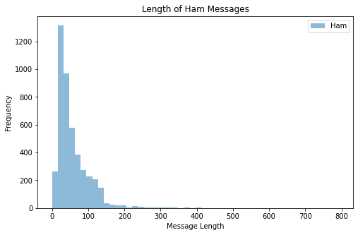

```python
import matplotlib.pyplot as plt
from sklearn.feature_extraction.text import CountVectorizer

# Calculate the length of each message in the 'message' column
df['message_length'] = df['Messages'].str.len()

# Separate ham messages based on the 'label' column
ham_lengths = df[df['Labels'] == 'ham']['message_length']

# Plot the lengths of ham messages
plt.figure(figsize=(8, 5))
plt.hist(ham_lengths, bins=50, alpha=0.5, label='Ham')
plt.xlabel('Message Length')
plt.ylabel('Frequency')
plt.title('Length of Ham Messages')
plt.legend()
plt.show()
```

Also, the length of the ham message was accessed.

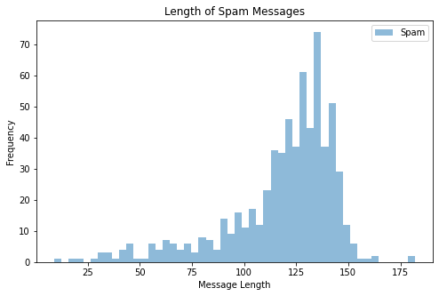

```python
# Calculate the length of each message in the 'message' column
df['message_length'] = df['Messages'].str.len()

# Separate spam and ham messages based on the 'label' column
spam_lengths = df[df['Labels'] == 'spam']['message_length']

# Plot the lengths of spam messages vs. ham messages
plt.figure(figsize=(8, 5))
plt.hist(spam_lengths, bins=50, alpha=0.5, label='Spam')
plt.xlabel('Message Length')
plt.ylabel('Frequency')
plt.title('Length of Spam Messages')
plt.legend()
plt.show()
```

The length of the spam message was accessed. When compared to the ham message the spam messages had longer length.

```python
cv = df['Messages']
# Initialize count vectorizer
vectorizer = CountVectorizer(analyzer='char_wb', ngram_range=(1, 1))

# Fit and transform the training data
X = vectorizer.fit_transform(df['Messages'])
X
```

```
<5169x45 sparse matrix of type '<class 'numpy.int64'>'
	with 94971 stored elements in Compressed Sparse Row format>
```

CountVectorizer was utilized to transform the messages by counting the occurrences of each character present in each message. The feature extraction parameters 'char_wb' and ngrams(1,1) were employed. 'char_wb' is a particular type of feature representation in which the text is divided into "n-grams" ofcharacters. The ngram_range parameter specifies the range of character n-grams that should be used in the vectorization process; in this case,CountVectorizer considers only 1-grams, also known as unigrams. To convert the text data into a numeric representation that can be easily processed bymachine learning algorithms, Vectorizer.fit_transform was used.

```python
X.shape
```

```
(5169, 45)
```

This was utilized to verify the dimensions of the feature matrix.

```python
print(X.toarray())
```

```
[[30  0  0 ...  0  0  0]
 [ 8  0  0 ...  0  0  0]
 [40  5  5 ...  0  0  0]
 ...
 [16  0  0 ...  0  0  0]
 [36  0  0 ...  0  0  0]
 [10  0  0 ...  0  0  0]]
```

```python
vectorizer.get_feature_names_out()
```

```
array([' ', '0', '1', '2', '3', '4', '5', '6', '7', '8', '9', '_', 'a',
       'b', 'c', 'd', 'e', 'f', 'g', 'h', 'i', 'j', 'k', 'l', 'm', 'n',
       'o', 'p', 'q', 'r', 's', 't', 'u', 'v', 'w', 'x', 'y', 'z', 'è',
       'é', 'ì', 'ú', 'ü', '〨', '鈥'], dtype=object)
```

This code prints out the sparse matrix as a 2-dimensional array where each row represents a vector of features and the columns represent the values of thosefeatures.

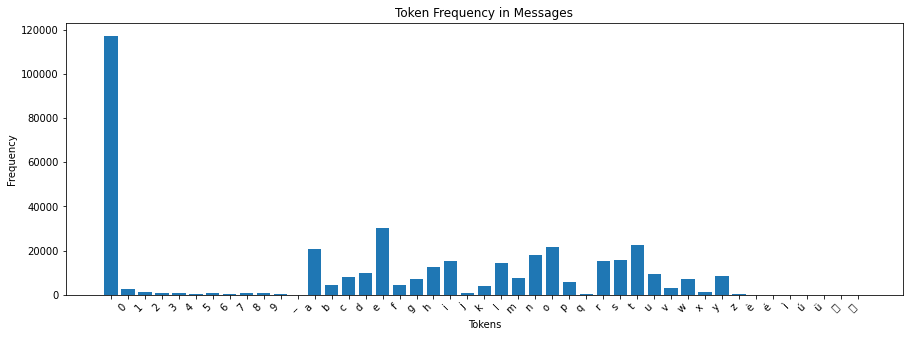

```python
# Get feature names and their counts
features = vectorizer.get_feature_names_out()
counts = np.asarray(X.sum(axis=0)).ravel()

# Create bar chart
fig, ax = plt.subplots(figsize=(15, 5))
ax.bar(features, counts)
ax.set_xlabel('Tokens')
ax.set_ylabel('Frequency')
ax.set_title('Token Frequency in Messages')
plt.xticks(rotation=45, ha='right')
plt.show()
```

This figure shows the features used to classify the message and occurrence.

```python
df["Labels"].unique()
```

```
array(['ham', 'spam'], dtype=object)
```

```python
LE=LabelEncoder()
y=LE.fit_transform(df["Labels"])
y
```

```
array([0, 0, 1, ..., 0, 0, 0])
```

Encoding was performed on the "Labels" variable to transform the data into numerical values that can be used as input for machine learning models.

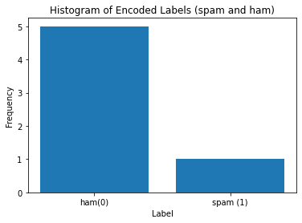

```python
labels = np.array(['ham', 'spam'], dtype=object)
predictions = np.array([0, 0, 1, ..., 0, 0, 0])

# Encode the labels
encoded_labels = np.arange(len(labels))

# Calculate the counts of spam and ham messages
ham_count = np.sum(predictions == encoded_labels[labels == 'ham'])
spam_count = np.sum(predictions == encoded_labels[labels == 'spam'])


# Plot the histogram with encoded data labels
plt.bar(['ham(' + str(encoded_labels[labels == 'ham'][0]) + ')', 'spam (' + str(encoded_labels[labels == 'spam'][0]) + ')'], [ ham_count, spam_count])
plt.xlabel('Label')
plt.ylabel('Frequency')
plt.title('Histogram of Encoded Labels (spam and ham)')
plt.show()
```

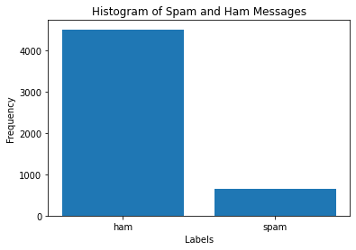

```python
# Calculate the counts of spam and ham messages
label_counts = df['Labels'].value_counts()

# Plot the histogram
plt.bar(label_counts.index, label_counts.values)
plt.xlabel('Labels')
plt.ylabel('Frequency')
plt.title('Histogram of Spam and Ham Messages')
plt.show()
```

This shows the number of labelled Spam and Ham messages.

```
Classification Report:
              precision    recall  f1-score   support

           0       0.91      0.95      0.93       133
           1       0.95      0.90      0.92       129

    accuracy                           0.93       262
   macro avg       0.93      0.93      0.93       262
weighted avg       0.93      0.93      0.93       262
```

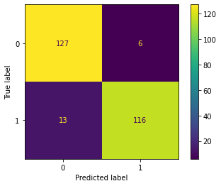

```python
from imblearn.under_sampling import RandomUnderSampler
from sklearn.model_selection import train_test_split
from sklearn.linear_model import LogisticRegression
from sklearn.metrics import classification_report, ConfusionMatrixDisplay
from sklearn import metrics


# Create the random under sampler
under_sampler = RandomUnderSampler()

# Resample the data to create a balanced dataset
X_balanced, y_balanced = under_sampler.fit_resample(X, y)

# Split the balanced dataset into training and testing sets
X_train, X_test, y_train, y_test = train_test_split(X_balanced, y_balanced, test_size=0.2, random_state=42)

# Create the logistic regression model
lr = LogisticRegression()

# Train the model on the balanced training set
lr.fit(X_train, y_train)

# Make predictions on the balanced testing set
predictions = lr.predict(X_test)

# Evaluate the performance of the model
print("Classification Report:")
print(classification_report(y_test, predictions))

# Plot the confusion matrix
cm = metrics.confusion_matrix(y_test, predictions)
disp = ConfusionMatrixDisplay(confusion_matrix=cm)
disp.plot()

plt.show()
```

The data was imbalanced, the data was balanced by using random under-sampling to create a more balanced dataset and then training the Classifier on the balanced data to classify SMS messages as spam or non-spam. The dataset was split into 20% test and 80% train.

```
Classification Report:
              precision    recall  f1-score   support

           0       0.93      0.97      0.95       133
           1       0.97      0.92      0.94       129

    accuracy                           0.95       262
   macro avg       0.95      0.95      0.95       262
weighted avg       0.95      0.95      0.95       262
```

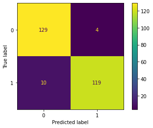

```python
from imblearn.under_sampling import RandomUnderSampler
from sklearn.model_selection import train_test_split
from sklearn.ensemble import RandomForestClassifier
from sklearn.metrics import classification_report, ConfusionMatrixDisplay

# Create the random under sampler
under_sampler = RandomUnderSampler()

# Resample the data to create a balanced dataset
X_balanced, y_balanced = under_sampler.fit_resample(X, y)

# Split the balanced dataset into training and testing sets
X_train, X_test, y_train, y_test = train_test_split(X_balanced, y_balanced, test_size=0.2, random_state=42)

# Create the random forest classifier
rfc = RandomForestClassifier()

# Train the model on the balanced training set
rfc.fit(X_train, y_train)

# Make predictions on the balanced testing set
predictions = rfc.predict(X_test)

# Evaluate the performance of the model
print("Classification Report:")
print(classification_report(y_test, predictions))

# Plot the confusion matrix
cm = metrics.confusion_matrix(y_test, predictions)
disp = ConfusionMatrixDisplay(confusion_matrix=cm)
disp.plot()

plt.show()
```

The data was imbalanced, the data was balanced by using random under-sampling to create a more balanced dataset and then training the Classifier on the balanced data to classify SMS messages as spam or non-spam. The dataset was split into 20% test and 80% train.

```
Classification Report:
              precision    recall  f1-score   support

           0       0.91      0.96      0.93       133
           1       0.96      0.90      0.93       129

    accuracy                           0.93       262
   macro avg       0.93      0.93      0.93       262
weighted avg       0.93      0.93      0.93       262
```

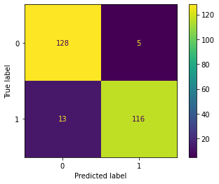

```python
from imblearn.under_sampling import RandomUnderSampler
from sklearn.model_selection import train_test_split
from sklearn.neural_network import MLPClassifier
from sklearn.metrics import classification_report, ConfusionMatrixDisplay

# Create the random under sampler
under_sampler = RandomUnderSampler()

# Resample the data to create a balanced dataset
X_balanced, y_balanced = under_sampler.fit_resample(X, y)

# Split the balanced dataset into training and testing sets
X_train, X_test, y_train, y_test = train_test_split(X_balanced, y_balanced, test_size=0.2, random_state=42)

# Create the MLP classifier
mlp = MLPClassifier()

# Train the model on the balanced training set
mlp.fit(X_train, y_train)

# Make predictions on the balanced testing set
predictions = mlp.predict(X_test)

# Evaluate the performance of the model
print("Classification Report:")
print(classification_report(y_test, predictions))

# Plot the confusion matrix
cm = metrics.confusion_matrix(y_test, predictions)
disp = ConfusionMatrixDisplay(confusion_matrix=cm)
disp.plot()

plt.show()
```

The data was imbalanced, the data was balanced by using random under-sampling to create a more balanced dataset and then training the Classifier on the balanced data to classify SMS messages as spam or non-spam. The dataset was split into 20% test and 80% train.

```
Ensemble Classifier:
Accuracy: 0.9351145038167938
              precision    recall  f1-score   support

           0       0.90      0.98      0.94       133
           1       0.97      0.89      0.93       129

    accuracy                           0.94       262
   macro avg       0.94      0.93      0.93       262
weighted avg       0.94      0.94      0.93       262
```

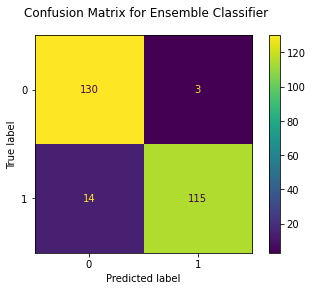

```python
from sklearn.ensemble import VotingClassifier
from sklearn.metrics import classification_report, confusion_matrix, accuracy_score

# Create the ensemble classifier using soft voting
ensemble_clf = VotingClassifier(estimators=[('clf1', lr), ('clf2', rfc), ('clf3', mlp)], voting='soft', weights=[1, 1, 1])

# Fit the ensemble classifier on the training data
ensemble_clf.fit(X_train, y_train)

# Make predictions using the ensemble classifier
ensemble_predictions = ensemble_clf.predict(X_test)

# Calculate accuracy
accuracy = accuracy_score(y_test, ensemble_predictions)

# Print accuracy, precision, recall, and confusion matrix for the ensemble classifier
print("Ensemble Classifier:")
print("Accuracy:", accuracy)
print(metrics.classification_report(y_test, ensemble_predictions))
ensemble_disp = metrics.plot_confusion_matrix(ensemble_clf, X_test, y_test)
ensemble_disp.figure_.suptitle("Confusion Matrix for Ensemble Classifier")

plt.show()
```

The prediction of each model was fed to the ensemble classifier to make the final prediction using soft voting. Each classifier had a weighted value of 1.

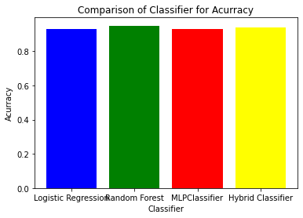

```python
# Create a list of the classifier names and their accuracies
classifiers = ['Logistic Regression', 'Random Forest', 'MLPClassifier','Hybrid Classifier']
# Precision scores for each classifier
accuracy_scores = [0.93, 0.95, 0.93, 0.94]
# Set the figure size
fig, ax = plt.subplots(figsize=(6, 4))
# Create a bar chart to compare the accuracies of the classifiers
ax.bar(classifiers, accuracy_scores, color=['blue', 'green', 'red', 'yellow'])
# Add labels and title to the chart
ax.set_xlabel('Classifier')
ax.set_ylabel('Acurracy')
ax.set_title('Comparison of Classifier for Acurracy')
# Show the chart
plt.show()
```

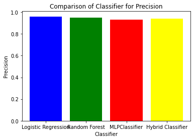

```python
# Create a list of the classifier names and their accuracies
classifiers = ['Logistic Regression', 'Random Forest', 'MLPClassifier','Hybrid Classifier']
# Precision scores for each classifier
precision_scores = [0.96, 0.95, 0.93, 0.94]
# Set the figure size
fig, ax = plt.subplots(figsize=(6, 4))
# Create a bar chart to compare the accuracies of the classifiers
ax.bar(classifiers, precision_scores, color=['blue', 'green', 'red', 'yellow'])
# Add labels and title to the chart
ax.set_xlabel('Classifier')
ax.set_ylabel('Precision')
ax.set_title('Comparison of Classifier for Precision')
# Show the chart
plt.show()
```

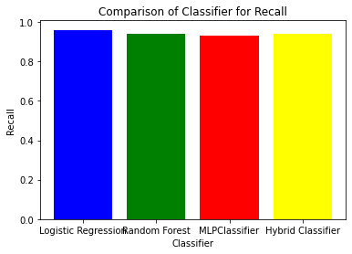

```python
# Create a list of the classifier names and their accuracies
classifiers = ['Logistic Regression', 'Random Forest', 'MLPClassifier','Hybrid Classifier']
# Precision scores for each classifier
recall_scores = [0.96, 0.94, 0.93, 0.94]
# Set the figure size
fig, ax = plt.subplots(figsize= (6, 4))
# Create a bar chart to compare the accuracies of the classifiers
ax.bar(classifiers, recall_scores, color=['blue', 'green', 'red', 'yellow'])
# Add labels and title to the chart
ax.set_xlabel('Classifier')
ax.set_ylabel('Recall')
ax.set_title('Comparison of Classifier for Recall')
# Show the chart
plt.show()
```

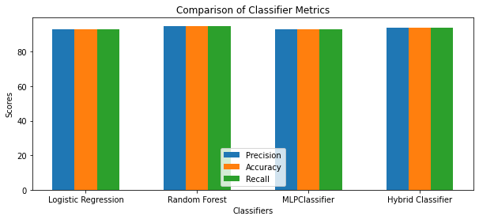

```python
import numpy as np
import matplotlib.pyplot as plt

data = [[93, 93, 93],
        [95, 95, 95],
        [93, 93, 93],
        [94, 94, 94]]

classifiers = ['Logistic Regression', 'Random Forest', 'MLPClassifier', 'Hybrid Classifier']
metrics = ['Precision', 'Accuracy', 'Recall']

X = np.arange(len(classifiers))
bar_width = 0.2

plt.figure(figsize=(10, 4))

for i, metric in enumerate(metrics):
    plt.bar(X + (i * bar_width), [row[i] for row in data], width=bar_width, label=metric)

plt.xlabel('Classifiers')
plt.ylabel('Scores')
plt.title('Comparison of Classifier Metrics')
plt.xticks(X + bar_width, classifiers)
plt.legend()

plt.show()
```

This graph compares each classifier performance.